# Analyze recurrence and impact of structural variants

Here, we want to find structural variants that reccur more than expected using fishhook. The positive control here is FGFR2 (fusions). We found a ton of hits but many of them seemed suspicious as functional drivers. So we overlapped the recurrence analysis with strctural variants that have a significant effect on expression (this is the same method undelrying the identification of expression quatitiative trait loci eQTL in germline analyses). The eQTL analysis also returned a ton of hits, but many were very rare with huge effect sizes. We also look at extrachromosomal DNA in this analysis.

## Data prep

Pull data from hpc

```r
#library(devtools)
#devtools::install_github('mskilab-org/gUtils')
#devtools::install_github('mskilab-org/fishHook')
#devtools::install_github('mskilab-org/gTrack')
#devtools::install_github('mskilab-org/skitools') ##corrupt
#BiocManager::install("ggbio")

suppressWarnings(
suppressPackageStartupMessages({

  library(rtracklayer)
  library(gTrack)
  library(BSgenome)
  library(BSgenome.Hsapiens.UCSC.hg38)
  library(ggbio)
  library(GenomicRanges)
  library(data.table)
  library(dplyr)
  library(reshape2)
  library(circlize)
  library(tidyr)
  library(PNWColors)
  library(ggrepel)

}))

'%ni%' <- function(x,y)!('%in%'(x,y))
code.dir = '~/Documents/scripts/github/btc-ccs/'
data.dir = '~/Documents/scripts/github/btc-ccs-data/'

source( file.path(data.dir, "paths.R"))
mount.dir = cluster.dir
cluster.dir = file.path(cluster.dir, 'users/fbeaudry/more.data')

source( file.path(code.dir, "bin/integrated_driver.functions.R"))

cohort.info <- fread(file.path(data.dir,"/results/samples.info.txt")) %>%
  dplyr::select(BTC_ID, Sample)

rerun.pulls = F
if(rerun.pulls){
  first.sv = T

  for(tumour_id in cohort.info$Sample){

    sv.cnv.file <- paste0(cluster.dir,tumour_id,'/sv.strict/',tumour_id,'.sv.cnv.txt')

    if(file.exists(sv.cnv.file)){
      message('processing ',tumour_id)

      sv.cnv <- fread(sv.cnv.file)

      if(first.sv ){
        full.sv.cnv<-sv.cnv
        first.sv=F
      }else{
        full.sv.cnv<-rbind.data.frame(full.sv.cnv,sv.cnv)
      }
    } else {
      message('skipping ',sv.cnv.file)
    }

  }

  full.sv.cnv$chr <- factor(full.sv.cnv$CHROM, levels = paste0('chr', c(c(1:22), 'X', 'Y')))

  write.table(
    full.sv.cnv,
    file = file.path(data.dir,'/results/sv.cnv.txt'),
    row.names = FALSE, quote = FALSE, sep = "\t"
  )

}
```

## breakpoint eQTL

Find structural variants that have a significant (and large) impact on nearby gene expression (+- 5000bp)

```r
predicted.w.score <- fread(file.path(data.dir,'/results/all.eCCS.txt') )

full.sv.cnv <- fread(file.path(data.dir,'/results/sv.cnv.txt'))
length(unique(full.sv.cnv$tumour))
```

```
## [1] 180
```

```r
filt.sv.cnv <- full.sv.cnv %>%
  filter(SUPPORT > 1 & VAF > 0.05 & !is.na(GENE)) %>%
  dplyr::select(tumour, CHROM, GENE, SV ) %>% unique()


write.table(
  filt.sv.cnv,
  file = paste0(data.dir, "/results/tableS9B.sv.txt"),
  row.names = FALSE, quote = FALSE, sep = "\t"
)

all.LBR.rna.df <- fread(file.path(data.dir,"/results/rna.tpm.ff.txt"), header = T)
all.LBR.rna <- as.matrix(all.LBR.rna.df[,-1])
rownames(all.LBR.rna) <- all.LBR.rna.df$gene_name

gene_set <- fread(file.path(data.dir,'/source_data/fgs.txt'))
gene_set$Chr <- paste0('chr', gene_set$Chr)
gene_list <- gene_set$gene_name[gene_set$biotype=="protein_coding" &
                                  gene_set$Length >= 500 &
                                  gene_set$Chr %in% paste0('chr',c(1:22)) &
                                  gene_set$gene_name %in% rownames(all.LBR.rna)
]

WINDOW_SIZE = 5000

run.eqtl = F
if(run.eqtl){

  sv.eqtl = NULL
  for(this.cms in c('all','CCS-A','CCS-B')){
    first.loop = T
    message('running ', this.cms)

    if(this.cms %in% c('CCS-A','CCS-B')){
      these.samples <- c(na.omit(predicted.w.score$Sample[predicted.w.score$rna_class == this.cms]))
      these.samples <- intersect(these.samples, colnames(all.LBR.rna))
      sub.LBR.rna <- all.LBR.rna[,these.samples]
    } else {
      sub.LBR.rna <- all.LBR.rna
    }

    for(this.gene in gene_list){
      #print(paste0(this.gene,' '))

      rearranged.tumours <- get.sv.window(this.gene, gene_set, WINDOW_SIZE,
                                          unclustered.sv = full.sv.cnv)

      this_rna <- sub.LBR.rna[this.gene,]
      this_rna_t <- as.data.frame(this_rna)
      this_rna_t$tumour <- rownames(this_rna_t)

      this_rna_t$is.sv <- 0
      this_rna_t$is.sv[this_rna_t$tumour %in% rearranged.tumours$tumour] <- 1

      if(all(sum(this_rna_t$is.sv) > 2 & sum(this_rna_t$this_rna) > 1) & sum(this_rna_t$is.sv) < nrow(this_rna_t)){

        this_rna_t <- this_rna_t %>%
          group_by(is.sv) %>%
          mutate(weight = 1 / n()) %>%
          ungroup()

        this_rna_t$weight_prop <- this_rna_t$weight / sum(this_rna_t$weight )

        tpm.sv.lm <- lm(log(as.numeric(this_rna) + 1) ~ is.sv, data=this_rna_t, weights = this_rna_t$weight_prop)
        tpm.sv.lm.summary <- summary(tpm.sv.lm)

        this.length = (gene_set$End[gene_set$gene_name == this.gene] + WINDOW_SIZE) - (gene_set$Start[gene_set$gene_name == this.gene] - WINDOW_SIZE)

        this.p <- cbind.data.frame('cms' = this.cms,
                                    'gene'=this.gene,

                                   'chr'=gene_set$Chr[gene_set$gene_name == this.gene],
                                   'win.start'=gene_set$Start[gene_set$gene_name == this.gene] - WINDOW_SIZE,
                                   'win.end'=gene_set$End[gene_set$gene_name == this.gene] + WINDOW_SIZE,
                                   'true_window_size' = this.length,
                                   'n'=length(unique(rearranged.tumours$tumour)),

                                   'lm.p'= tpm.sv.lm.summary$coefficients[2,4],
                                   'lm.fstat' = tpm.sv.lm.summary$fstatistic[['value']],
                                   'lm.estimate' = tpm.sv.lm.summary$coefficients[2,1],
                                   'lm.tstat' = tpm.sv.lm.summary$coefficients[2,3]
        )


        if(first.loop){ccs.sv.eqtl <- this.p; first.loop=F} else {ccs.sv.eqtl <- rbind.data.frame(ccs.sv.eqtl, this.p)}


      }

  }

    ccs.sv.eqtl$eqtl.fdr <- p.adjust(ccs.sv.eqtl$lm.p, method = "BH")
    if(is.null(sv.eqtl)){sv.eqtl <- ccs.sv.eqtl} else {sv.eqtl <- rbind.data.frame(sv.eqtl, ccs.sv.eqtl)}

  }

  write.table(
    sv.eqtl,
    file = paste0(data.dir, "/results/sv.eqtl.txt"),
    row.names = FALSE, quote = FALSE, sep = "\t"
  )
}
```

## evaluate SV eQTL

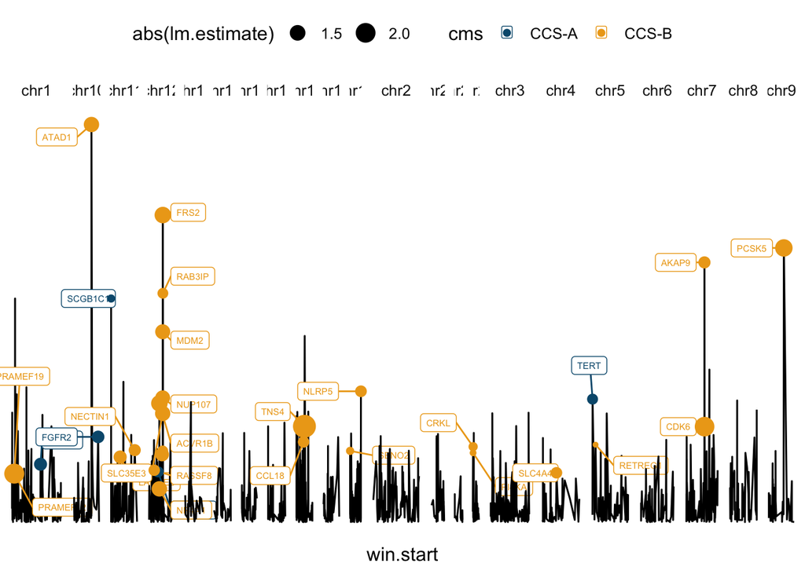

```r
sv.eqtl <- fread(paste0(data.dir, "/results/sv.eqtl.txt"))

sv.eqtl$chr_fac <- factor(gsub("chr","",sv.eqtl$chr), levels=c(1:22,'X'))

large.sv.eqtl <- sv.eqtl %>% filter(eqtl.fdr < 0.05 & abs(lm.estimate) > 1)

ggplot(sv.eqtl %>% filter(cms != 'all'), aes(y=-log(eqtl.fdr), x=win.start)) +

  geom_line()+
  facet_grid(.~chr, space='free',scales='free')+

  geom_label_repel(aes(label=gene,color=cms),    data = ~ subset(., eqtl.fdr < 0.05 & abs(lm.estimate) > 1), size=2,
                  box.padding = 1, force = 4, max.time = 2,  min.segment.length = 0) +

  geom_point(   data = ~ subset(., eqtl.fdr < 0.05 & abs(lm.estimate) > 1), aes(color=cms, size=abs(lm.estimate) )) +

  scale_color_manual(values = c(
    "all" = 'grey',
    "CCS-B"    = "#EDA71A" ,
    "CCS-A" = "#04597C"
  )) +
  theme_bw(base_size=12) +
  theme(strip.background = element_blank(),

        panel.spacing.y = unit(0,'lines'),
        legend.position="top",

        axis.title.y =element_blank(),
        axis.text=element_blank(),
        axis.ticks  =element_blank(),
        panel.grid.major = element_blank(),
        panel.grid.minor = element_blank(),
        panel.background = element_rect(fill='transparent'), #transparent panel bg
        plot.background = element_rect(fill='transparent', color='transparent'), #transparent plot bg
        panel.border = element_blank(),

        #strip.text.x = element_blank(),
        strip.text.y = element_text(size = 18, angle = 0),
        strip.placement = "outside") + coord_cartesian(clip = "off")
```

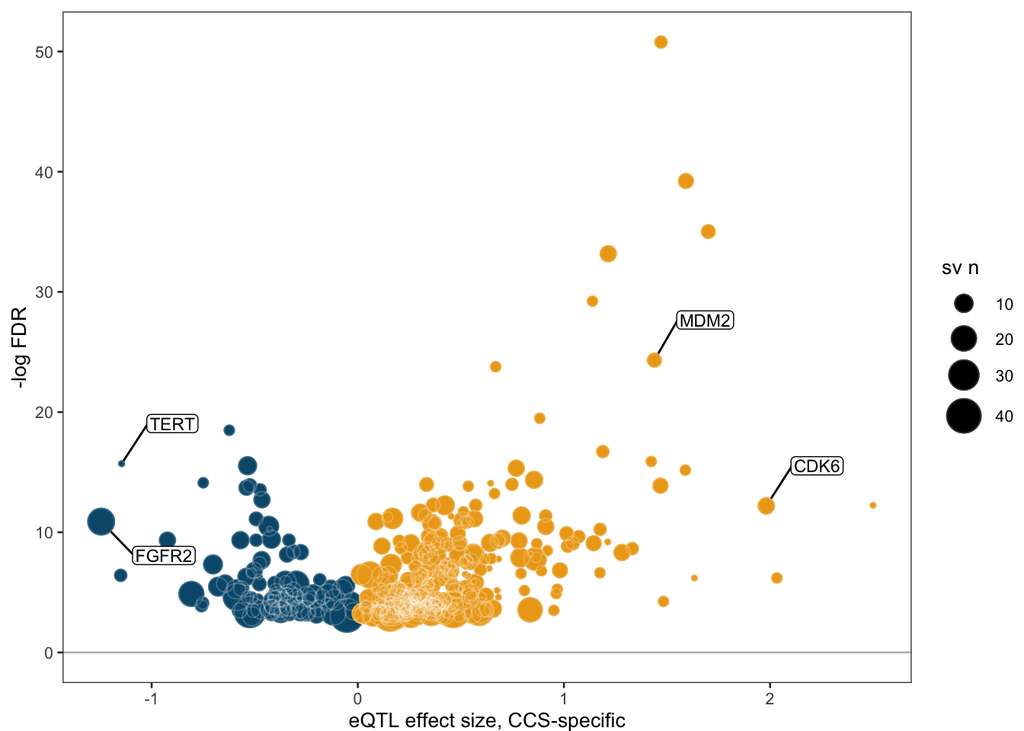

```r
sv.eqtl.cms <- sv.eqtl %>% filter(cms != 'all' & eqtl.fdr < 0.05 & n < 50 )
sv.eqtl.cms$effect.size.mod <- abs(sv.eqtl.cms$lm.estimate)
sv.eqtl.cms$effect.size.mod[sv.eqtl.cms$cms == 'CCS-A'] <- -sv.eqtl.cms$effect.size.mod[sv.eqtl.cms$cms == 'CCS-A']

eqtl.n <- sv.eqtl.cms %>% group_by(gene) %>% tally()

sv.eqtl.cms <- sv.eqtl.cms %>% filter(gene %ni% eqtl.n$gene[eqtl.n$n > 1])

sv.eqtl.cms$Gene <- factor(sv.eqtl.cms$gene, levels=sv.eqtl.cms$gene[order(sv.eqtl.cms$effect.size.mod)])

sv.eqtl.plot <-
ggplot(sv.eqtl.cms, aes(x = effect.size.mod, y = -log(eqtl.fdr))) +
  geom_hline(yintercept = 0, color='grey')+


  geom_point(aes(color=cms, size=n)) +
  geom_point(aes( size=n), shape=1, color='white', stroke = 0.5, alpha=0.2) +

    geom_label_repel(aes(label=gene),
                   data = ~ subset(., gene %in% c('TERT','CDK6','FGFR2','MDM2')),
                   size=3,   label.padding = 0.1,
                   box.padding = 1, force = 4,
                   max.time = 2,  min.segment.length = 0) +

    geom_point(data = ~ subset(., gene %in% c('TERT','CDK6','FGFR2','MDM2')),
               aes(color=cms, size=n)) +
  geom_point(data = ~ subset(., gene %in% c('TERT','CDK6','FGFR2','MDM2')),
             aes( size=n), shape=1, color='white', stroke = 0.5, alpha=0.2) +

  scale_color_manual(values = c(
    "all" = 'grey',
    "CCS-B"    = "#EDA71A" ,
    "CCS-A" = "#04597C"
  )) +
  theme_bw(base_size=10) +
  guides(color='none')+
  scale_size(range = c(1,8))  +

  theme(

    plot.margin = unit(c(2, 0, 0, 2), "mm"),

    panel.grid.major = element_blank(),
    panel.grid.minor = element_blank(),
    panel.background = element_rect(fill='transparent'), #transparent panel bg
    plot.background = element_rect(fill='transparent', color='transparent'), #transparent plot bg

) + labs(x='eQTL effect size, CCS-specific', y='-log FDR', size='sv n')

sv.eqtl.plot
```

```r
ggsave(paste0(data.dir, "/results/fig/FIGS4b.sv.eqtl.svg"), plot =
         sv.eqtl.plot
, device = "svg",width = 100, height = 90 , units='mm' , dpi=72 )

sv.eqtl.cms %>% filter( gene %in% c('TERT','EGFR','CDK6','FGFR2','MDM2','TP53','DCDC2','RB1'))
```

```
##       cms   gene    chr win.start   win.end true_window_size     n         lm.p
##    <char> <char> <char>     <int>     <num>            <num> <int>        <num>
## 1:  CCS-A   TERT   chr5   1248147   1300068            51921     3 1.300564e-09
## 2:  CCS-A  DCDC2   chr6  24166755  24363059           196304    11 4.568933e-03
## 3:  CCS-A  FGFR2  chr10 121473332 121603458           130126    23 4.851468e-07
## 4:  CCS-B   CDK6   chr7  92599921  92841573           241652     8 1.335492e-07
## 5:  CCS-B   MDM2  chr12  68803177  68855686            52509     6 1.555776e-13
## 6:  CCS-B    RB1  chr13  48298726  48604436           305710     8 2.698469e-09
##     lm.fstat lm.estimate  lm.tstat     eqtl.fdr chr_fac effect.size.mod   Gene
##        <num>       <num>     <num>        <num>  <fctr>           <num> <fctr>
## 1: 53.411885   1.1456955  7.308344 1.503452e-07       5      -1.1456955   TERT
## 2:  8.758203   0.4721413  2.959426 2.779835e-02       6      -0.4721413  DCDC2
## 3: 32.669123   1.2448949  5.715691 1.869432e-05      10      -1.2448949  FGFR2
## 4: 35.740308   1.9818384  5.978320 5.051021e-06       7       1.9818384   CDK6
## 5: 89.855126   1.4387468  9.479194 2.745944e-11      12       1.4387468   MDM2
## 6: 48.730194  -0.7687382 -6.980702 2.198215e-07      13       0.7687382    RB1
```

## ecDNA

How common is extra-chromosomal DNA and how does it align with our eQTL?

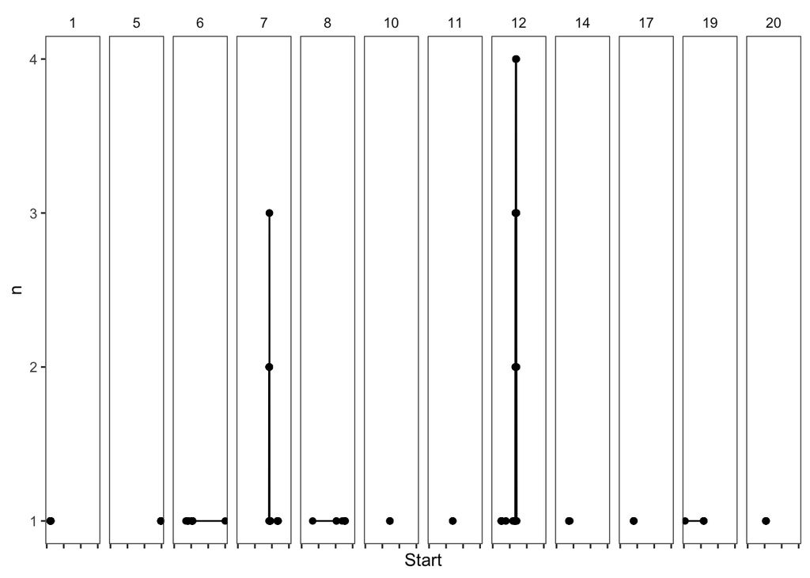

```r
split_string <- function(input_string) {
  # Remove the square brackets and single quotes, then split by comma
  items <- strsplit(gsub("\\['|\\']", "", input_string), ",")[[1]]
  # Trim any leading or trailing whitespace from each item
  items <- trimws(items)
  items <- gsub("'", "", items)
  return(items)
}

rerun.pulls = F
local.run = T

if(rerun.pulls){

  sample_list <- read.table(file.path(basedir,'/source_data/sample.list.txt'), header=F)

  first.loop = T
  first.ecDNA = T
  for(tumour_id in sample_list$V2){

    cat('\n\nprocessing ',tumour_id,'\n')
    donor_id <- sample_list$V1[sample_list$V2 == tumour_id]

    #cluster here will be a mush of ("population/tumour-specific") hotspots
    #and complex rearrangements
    #should I stratify clusters for VAF?
    this.sv.cnv.path <- paste0(cluster.dir,tumour_id,'/sv.strict/',tumour_id,'.sv.cnv.txt')

    #amplicon-architect, by definition, filters for CNV clusters (first)
    #so SV-only clusters won't show up
    this.sample.amplicons.path <- paste0(cluster.dir
                                         ,tumour_id,'/amplicon/results/',tumour_id,'_classification/',
                                         tumour_id, '_result_table.tsv')

    if(file.exists(this.sv.cnv.path) & file.exists(this.sample.amplicons.path)){

      this.sv.cnv <- fread(this.sv.cnv.path)

      this.sample.amplicons <- fread(this.sample.amplicons.path)
      this.sample.amplicons <- this.sample.amplicons[!is.na(this.sample.amplicons$`AA amplicon number`),]

      if(nrow(this.sample.amplicons) > 0){

        for(this.amplicon.id in this.sample.amplicons$`Feature ID`){

          this.bed.file <- this.sample.amplicons$`Feature BED file`[this.sample.amplicons$`Feature ID` == this.amplicon.id]

          #if R is running on cluster, set to False
          if(local.run){this.bed.file <- sub('^.*?/(users|pipeline|references)/', file.path(mount.dir, '\\1/'), this.bed.file, perl = TRUE)}

          #TODO: this was a patch for a change in directory structure (25/06/20),
          #can eventually be deleted
          if(!file.exists(this.bed.file)){this.bed.file <- gsub('/amplicon/','/amplicon/results/',this.bed.file)}

          ##read bed file
          this.bed <- fread(this.bed.file)

          ##check how often AA calls overlap with SV calls
          for(this.chrom in unique(this.bed$V1)){

            sub.bed <- this.bed[this.bed$V1 == this.chrom,]
            this.start <- sub.bed$V2[1] - 200000
            this.end <- sub.bed$V3[nrow(sub.bed)] + 200000

            this.caught.in.cluster <- this.sv.cnv[this.sv.cnv$CHROM == this.chrom &
                                                    this.sv.cnv$POS >= this.start &
                                                    this.sv.cnv$POS <= this.end]

            this.caught.in.cluster$amplicon.id <- this.sample.amplicons$`AA amplicon number`[this.sample.amplicons$`Feature ID` == this.amplicon.id]
            this.caught.in.cluster$amplicon.type <- this.sample.amplicons$Classification[this.sample.amplicons$`Feature ID` == this.amplicon.id]

            if(nrow(this.caught.in.cluster) == 0){
              cat('no SVs at all in ',this.amplicon.id,'\n')
            }

            if(first.loop){caught.in.cluster <- this.caught.in.cluster; first.loop = F} else {
              caught.in.cluster <- rbind.data.frame(caught.in.cluster, this.caught.in.cluster)
            }
          }

          ## pull ecDNA out seperatly
          if(this.sample.amplicons$Classification[this.sample.amplicons$`Feature ID` == this.amplicon.id] == 'ecDNA'){

            cat('ecDNA found!\n')
            thi.gene_list <- split_string(this.sample.amplicons$`All genes`[this.sample.amplicons$`Feature ID` == this.amplicon.id])
            this.ecdna.genes <- cbind.data.frame(tumour_id, this.amplicon.id, thi.gene_list )

            if(first.ecDNA){ecdna.genes <- this.ecdna.genes; first.ecDNA = F} else {
              ecdna.genes <- rbind.data.frame(ecdna.genes, this.ecdna.genes)
            }
          }
        }
      } else { cat('no amplicons')}
    } else { cat('file missing')}
  }


  write.table(
    ecdna.genes,
    file = file.path(data.dir,'/results/ecdna.genes.txt'),
    row.names = FALSE, quote = FALSE, sep = "\t"
  )

}

ecdna.genes <- fread(file.path(data.dir,'/results/ecdna.genes.txt'))

ecdna.genes.tally <- ecdna.genes %>% group_by(tumour_id, thi.gene_list) %>% tally()
ecdna.genes.tally <- ecdna.genes.tally %>% group_by( thi.gene_list) %>% tally()
ecdna.genes.tally <- ecdna.genes.tally %>% filter(thi.gene_list != '[]' )

gene_set <- fread(file.path(data.dir,'/source_data/fgs.txt'))
ecdna.genes.tally <- left_join(ecdna.genes.tally, gene_set, by=c('thi.gene_list'='gene_name'))

ggplot(ecdna.genes.tally %>% filter(!is.na(Chr)), aes(x=Start, y=n)) +
  geom_point()+
  geom_line()+
  facet_grid(.~Chr)+
  theme_bw() + theme(panel.grid = element_blank(),
                     axis.text.x = element_blank(),

                     strip.background = element_blank())
```

```r
ecdna.genes.tally %>% arrange(desc(n)) %>% filter(Chr == 12)
```

```
## # A tibble: 54 × 9
##    thi.gene_list     n ensid             Chr  Start    End strand biotype Length
##    <chr>         <int> <chr>           <int>  <int>  <int> <chr>  <chr>    <int>
##  1 CPM               4 ENSG00000135678    12 6.88e7 6.90e7 -      protei… 129374
##  2 DYRK2             4 ENSG00000127334    12 6.76e7 6.77e7 +      protei…  17069
##  3 IFNG              4 ENSG00000111537    12 6.82e7 6.82e7 -      protei…   4973
##  4 IFNG-AS1          4 ENSG00000255733    12 6.80e7 6.82e7 +      lncRNA  245242
##  5 IL22              4 ENSG00000127318    12 6.82e7 6.83e7 -      protei…   5363
##  6 IL26              4 ENSG00000111536    12 6.82e7 6.82e7 -      protei…  24462
##  7 MDM1              4 ENSG00000111554    12 6.83e7 6.83e7 -      protei…  59939
##  8 MDM2              4 ENSG00000135679    12 6.88e7 6.89e7 +      protei…  42510
##  9 NUP107            4 ENSG00000111581    12 6.87e7 6.87e7 +      protei…  58859
## 10 RAP1B             4 ENSG00000127314    12 6.86e7 6.87e7 +      protei…  61047
## # ℹ 44 more rows
```

```r
ecdna.genes.tally %>% arrange(desc(n)) %>% filter(Chr == 7)
```

```
## # A tibble: 47 × 9
##    thi.gene_list     n ensid             Chr  Start    End strand biotype Length
##    <chr>         <int> <chr>           <int>  <int>  <int> <chr>  <chr>    <int>
##  1 CDK6              3 ENSG00000105810     7 9.26e7 9.28e7 -      protei… 231653
##  2 CDK6-AS1          3 ENSG00000237819     7 9.28e7 9.29e7 +      lncRNA   80705
##  3 FAM133B           3 ENSG00000234545     7 9.26e7 9.26e7 -      protei…  29636
##  4 AKAP9             2 ENSG00000127914     7 9.19e7 9.21e7 +      protei… 169812
##  5 ANKIB1            2 ENSG00000001629     7 9.22e7 9.24e7 +      protei… 155410
##  6 CYP51A1           2 ENSG00000001630     7 9.21e7 9.21e7 -      protei…  22651
##  7 CYP51A1-AS1       2 ENSG00000188693     7 9.21e7 9.22e7 +      lncRNA   46122
##  8 ERVW-1            2 ENSG00000242950     7 9.25e7 9.25e7 -      protei…   9607
##  9 GATAD1            2 ENSG00000157259     7 9.24e7 9.25e7 +      protei…  12594
## 10 KRIT1             2 ENSG00000001631     7 9.22e7 9.22e7 -      protei…  47198
## # ℹ 37 more rows
```

## ecDNA

Compare frequency of extrachromosomal DNA

```r
ecdna.n <- ecdna.genes %>% dplyr::select(tumour_id, this.amplicon.id) %>%
                        unique() %>% group_by(tumour_id) %>% tally()

#TODO: ensure sample was run
ecdna.n.split <- left_join(predicted.w.score, ecdna.n, by=c('Sample'='tumour_id')) %>%
  filter(!is.na(rna_class) & Sample %in% cohort.info$Sample)

ecdna.n.split$n[is.na(ecdna.n.split$n)] <- 0

ecdna.n.split$n.bin[ecdna.n.split$n == 0] <- 'No ecDNA'
ecdna.n.split$n.bin[ecdna.n.split$n > 0] <- 'ecDNA+'

ecdna.n.split %>% group_by(rna_class) %>% summarise(mean.n = mean(n))
```

```
## # A tibble: 2 × 2
##   rna_class mean.n
##   <chr>      <dbl>
## 1 CCS-A     0.0308
## 2 CCS-B     0.225
```

```r
ecdna.groups <- ecdna.n.split %>%
  filter(!is.na(rna_class)) %>%
  dplyr::count(rna_class, n.bin) %>%
  complete(rna_class, n.bin, fill = list(n = 0)) %>%
  group_by(rna_class) %>%
  mutate(total = sum(n),
         relative_freq = n / total) %>%
  rowwise() %>%
  mutate(ci = list(binom.test(n, total)$conf.int)) %>%
  unnest_wider(ci, names_sep = "_") %>%
  ungroup() %>%
  filter(n.bin != 'No ecDNA')

ecdna.n.split %>%
  dplyr::select(rna_class  ,  n.bin) %>%
  table() %>% fisher.test()
```

```
##
##  Fisher's Exact Test for Count Data
##
## data:  .
## p-value = 0.0006104
## alternative hypothesis: true odds ratio is not equal to 1
## 95 percent confidence interval:
##  0.001486686 0.449597251
## sample estimates:
## odds ratio
## 0.06457557
```

## run fishhook

Run recurrence analysis and combine with eQTL results.

You may notice RHD comes up as the second hit after FGFR2. This is statistically accurate but upon manual review of some of the cases with this variant, we found it was just a common germline variant, aka the one defining blood groups. This also felt like a good, although unexpected, proof-of-concept (although suggests some leakage of germline variants into our somatic sv calls).

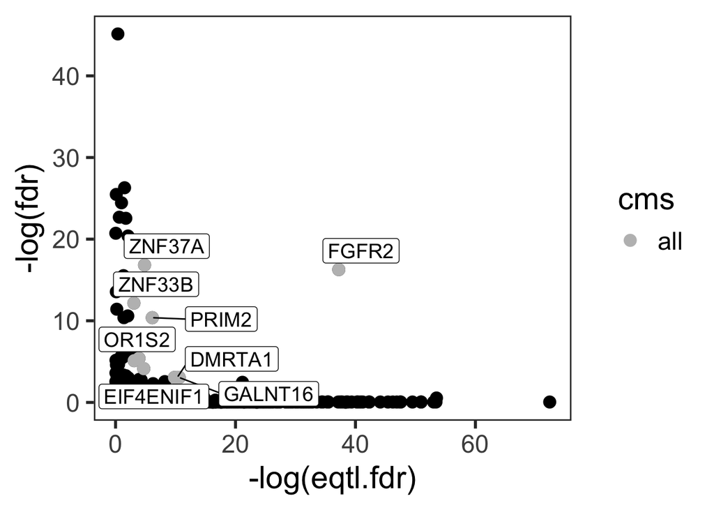

```r
run_fishhook = F

if(run_fishhook){

  ## careful, the fishHook package over-writes a bunch of base functions
  ## and you basically have to restart your environment to run anything else
  library(fishHook)
  packageVersion('fishHook')

  dndscv_reference_data_path <- file.path(data.dir,'/source_data/dndscv_data/data/RefCDS_human_GRCh38_GencodeV18_recommended.rda')
  load(file=dndscv_reference_data_path)

  genes <- gr_genes
  current_seqlevels <- seqlevels(genes)
  new_seqlevels <- paste0('chr', current_seqlevels)
  seqlevels(genes) <- new_seqlevels

  ## Reading in mutation calls from WGS

  raw.full.sv.cnv <- fread(file.path(data.dir,'/results/sv.cnv.txt'))
  full.sv.cnv <- raw.full.sv.cnv %>% filter(SUPPORT > 1)

  for(this.cms in c('all')){


    mutations.wgs <- GRanges(
      seqnames = full.sv.cnv$CHROM,
      ranges = IRanges(start = full.sv.cnv$POS, end = full.sv.cnv$POS),
      Variant_Type = full.sv.cnv$SV,
      uuid = full.sv.cnv$tumour
    )

    genome(mutations.wgs) <- "hg38"
    seqlengths(mutations.wgs) <- seqlengths(BSgenome.Hsapiens.UCSC.hg38)[seqlevels(mutations.wgs)]

    tiles = gr.tile(seqinfo(mutations.wgs), WINDOW_SIZE)

    # %+% is a gUtils operator that shifts ech GRange by given distance
    # Here we create additional GRanges by shifting all tiles by 5000 Kb
    supertiles = c(tiles, tiles %+% 5000)

    ## Annotating by nearest gene
    supertiles$nearest.gene = genes$names[nearest(supertiles, gr.stripstrand(genes))]


    ## Supertiles
    fish.supertiles.snv = Fish(hypotheses = supertiles,
                               events = mutations.wgs,
                               idcol = 'uuid',
                               #use_local_mut_density = TRUE,
                               mc.cores = 40)



    fish.supertiles.snv = fish.supertiles.snv[fish.supertiles.snv$data$frac.eligible > 0.75, ]
    fish.supertiles.snv$score()

    p1 = fish.supertiles.snv$qqp(plotly = FALSE)
    fish.res <- gr2dt(fish.supertiles.snv$res)[order(p), ]

    fish.res.gene <- fish.res %>%
      group_by(nearest.gene) %>%
      filter(fdr == min(fdr) & p == min(p)) %>%
      dplyr::select(nearest.gene, p   , fdr ,count, effectsize, count.pred)

    fish.res.gene <- unique(fish.res.gene)
    fish.res.gene$cms <- this.cms

    if(this.cms == 'all'){all.fish.res.gene <- fish.res.gene} else {
      all.fish.res.gene <- rbind.data.frame(all.fish.res.gene, fish.res.gene)
    }

  }

  write.table(
    all.fish.res.gene,
    file = file.path(data.dir, "/results/fish.res.gene.txt"),
    row.names = FALSE, quote = FALSE, sep = "\t"
  )
}

all.fish.res.gene <- fread(file.path(data.dir, "/results/fish.res.gene.txt"))

sv.fishhook <- left_join(sv.eqtl, all.fish.res.gene, by=c('gene'='nearest.gene','cms'='cms'))

ggplot(sv.fishhook %>% filter(cms == 'all'), aes(x=-log(eqtl.fdr),-log(fdr))) +
  geom_point()+
  geom_point(aes(color=cms),  data = ~ subset(., (eqtl.fdr < 0.05 & fdr < 0.05)  )) +
  geom_label_repel(aes(label=gene),    data = ~ subset(., (eqtl.fdr < 0.05 & fdr < 0.05)  ), size=5) +
  theme_bw(base_size=22) +
  theme(
    panel.grid.major = element_blank(),
    panel.grid.minor = element_blank(),
    panel.background = element_rect(fill='transparent'), #transparent panel bg
    plot.background = element_rect(fill='transparent', color='transparent') #transparent plot bg
  ) +


  scale_color_manual(values = c(
    "all" = 'grey',
    "CCS-B"    = "#EDA71A" ,
    "CCS-A" = "#04597C"
  ))
```

```r
sv.fishhook %>% filter(gene == 'FGFR2')
```

```
##       cms   gene    chr win.start   win.end true_window_size     n         lm.p
##    <char> <char> <char>     <int>     <num>            <num> <int>        <num>
## 1:    all  FGFR2  chr10 121473332 121603458           130126    23 8.107434e-19
## 2:  CCS-A  FGFR2  chr10 121473332 121603458           130126    23 4.851468e-07
##     lm.fstat lm.estimate  lm.tstat     eqtl.fdr chr_fac       p     fdr count
##        <num>       <num>     <num>        <num>  <fctr>   <num>   <num> <int>
## 1: 110.05462    1.910627 10.490692 6.882311e-17      10 6.9e-12 8.6e-08    20
## 2:  32.66912    1.244895  5.715691 1.869432e-05      10      NA      NA    NA
##    effectsize count.pred
##         <num>      <num>
## 1:       7.75     0.0927
## 2:         NA         NA
```